# cs2

**TGS Salt Identification**

This competition is about finding salt or no salt in the given seismic images.This task requires us to label every pixel thus this is a case for semantic segmentation.

**Data Acquisition**

https://www.kaggle.com/c/tgs-salt-identification-challenge/data

**Evaluation Metric**

Metric used is Mean Average Precision over different IOU Thresholds.

```python
from google.colab import drive
drive.mount('/content/drive')
```

```python
!pip install albumentations==0.4.6
!pip install tensorboardX
!pip install tensorboard
```

```
     |████████████████████████████████| 122kB 9.0MB/s
     |████████████████████████████████| 952kB 9.3MB/s
  Found existing installation: imgaug 0.2.9
    Uninstalling imgaug-0.2.9:
      Successfully uninstalled imgaug-0.2.9
  Found existing installation: albumentations 0.1.12
    Uninstalling albumentations-0.1.12:
      Successfully uninstalled albumentations-0.1.12
     |████████████████████████████████| 317kB 8.5MB/s
```

```python
import os
import numpy as np
import imageio
import matplotlib.pyplot as plt
import pandas as pd
import random
import math
import time
import pickle
from sklearn.model_selection import StratifiedKFold,train_test_split
from tqdm import tqdm
from datetime import datetime
import cv2
from pathlib import Path
import time
import torch
import torch.nn as nn
import torchvision
import torch.nn.functional as F
import torch.optim as optim
from torchvision import datasets, transforms,models
from torch.utils import data
from torch.utils.data import random_split
from  torchsummary import summary
from torch.utils.tensorboard import SummaryWriter
from tensorboardX import SummaryWriter
from albumentations import Compose, RandomCrop, Normalize, HorizontalFlip, Resize,PadIfNeeded,RandomBrightness,Rotate,OneOf
from albumentations.pytorch import ToTensor
from matplotlib.image import imread
import PIL.Image
from albumentations.augmentations.transforms import Blur,RandomContrast,ShiftScaleRotate,Cutout,VerticalFlip,RandomGamma,RandomResizedCrop
from albumentations.pytorch.transforms import ToTensorV2
```

```python
import warnings
warnings.filterwarnings("ignore", category=UserWarning)
```

```python
%cd '/content/drive/My Drive/workspace'
```

```
/content/drive/My Drive/workspace
```

```python
#for replicting results
seed=3
def set_seed(seed=3):
  torch.manual_seed(seed)
  torch.cuda.manual_seed(seed)
  np.random.seed(seed)  # Numpy module.
  random.seed(seed)  # Python random module.
  torch.manual_seed(seed)
  torch.backends.cudnn.benchmark = False
  torch.backends.cudnn.deterministic = True
  os.environ['PYTHONHASHSEED'] = str(seed)
```

```python
#used for reproducing results
def _init_fn(worker_id):
    np.random.seed(int(seed))
```

### Common

#### Dataset

```python
mask_path= '/content/drive/MyDrive/competition_data/train/masks/2ffea0c397.png'
image_path='/content/drive/MyDrive/competition_data/train/images/2ffea0c397.png'
image=PIL.Image.open(image_path).convert('RGB')
image= np.array(image).astype(np.float32)
print(imread(mask_path)[:5,:5]),print((image)[0,:5,:5])
```

```
[[0. 0. 0. 0. 0.]
 [0. 0. 0. 0. 0.]
 [0. 0. 0. 0. 0.]
 [0. 0. 0. 0. 0.]
 [0. 0. 0. 0. 0.]]
[[168. 168. 168.]
 [174. 174. 174.]
 [176. 176. 176.]
 [177. 177. 177.]
 [179. 179. 179.]]
```

```
(None, None)
```

X represents 3x101x101 dimension images,Y represents with 101x101 binary masks,X has 0 to 255 range values, Y has 0,1

```python
directory= "../competition_data"
depths_df = pd.read_csv(os.path.join(directory, 'trainanddepth.csv'))
depth= pd.read_csv(os.path.join(directory, 'depths.csv'))
train_path = os.path.join(directory, 'train')
file_list = list(depths_df['id'].values)
```

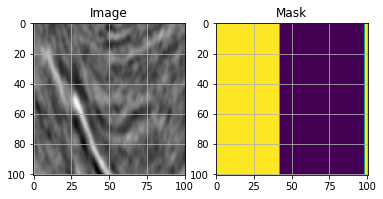

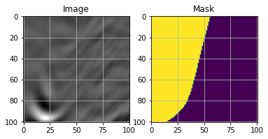

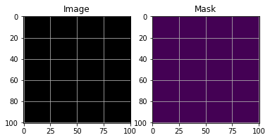

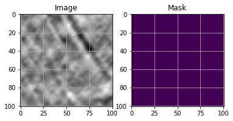

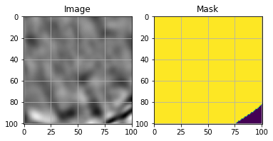

As above some anamolies(outliers) present such as vertical masks,black images with empty masks.

Change in brightness and contrast between images can be observed, blur of images can also be observed.

```python
#salt content over the data 1 refers to <=10% salt
coverage= depths_df['salt_content'].values
```

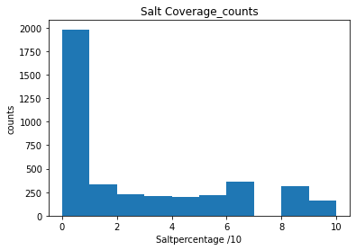

```python
plt.hist(coverage)
plt.title('Salt Coverage_counts')
plt.xlabel('Saltpercentage /10')
plt.ylabel('counts')
```

Abnormal amounts of no salt present.This problem can also be posed as finding no salt first and then applying semantic segmenation pipeline only on those masks for which salt is actually present.

```python
#most basic transforms
def_transforms= Compose([
    PadIfNeeded(128,128,cv2.BORDER_REPLICATE),
    Normalize(mean=(0,0,0),std=(1,1,1,))])
```

```python
class TGSSaltDataset(data.Dataset):
    def __init__(self, root_path, file_list, is_test = False,augment= def_transforms,dpsv=False):
        self.is_test = is_test
        self.root_path = root_path
        self.file_list = file_list
        self.augment= augment
        self.dpsv= dpsv
    def __len__(self):
        return len(self.file_list)

    def __getitem__(self, index):

        file_id = self.file_list[index]

        image_folder = os.path.join(self.root_path, "images")
        image_path = os.path.join(image_folder, file_id + ".png")

        mask_folder = os.path.join(self.root_path, "masks")
        mask_path = os.path.join(mask_folder, file_id + ".png")

        image = PIL.Image.open(image_path).convert('RGB')
        image= np.array(image).astype(np.float32)
        image=np.clip(image - np.median(image) +127, 0, 255)#remove all the noise which inherently exists in the data
        if self.is_test:
            data= {"image":image}
            X= self.augment(**data)
            image= X["image"]
            return torch.FloatTensor(image).permute(2,0,1)
        else:
            mask= imread(mask_path)
            mask= np.array(mask)
            data= {"image":image,"mask":mask}
            X= self.augment(**data)
            if self.dpsv:
              others=get_others(X['mask'])
              return (torch.FloatTensor(X["image"]).permute(2,0,1),*others)

            image,mask= torch.FloatTensor(X["image"]).permute(2,0,1),torch.FloatTensor(X["mask"]).unsqueeze(0)

            return (image, mask)
```

#### kaggle metric

```python
#https://www.kaggle.com/c/tgs-salt-identification-challenge/discussion/67693
def iou_metric(outputs, labels,logits=True):
    outputs,labels= size_correct(outputs,labels)
    outputs= (outputs>0).detach().cpu().numpy() if logits else (outputs>.5).detach().cpu().numpy()
    labels= labels.detach().cpu().numpy()
    batch_size = outputs.shape[0]
    metric = 0.0
    for batch in range(batch_size):
        t, p = labels[batch], outputs[batch]
        true = np.sum(t)
        pred = np.sum(p)

        # deal with empty mask first
        if true == 0:
            metric += (pred == 0)
            continue

        # non empty mask case.  Union is never empty
        # hence it is safe to divide by its number of pixels
        intersection = np.sum(t * p)
        union = true + pred - intersection
        iou = intersection / union

        # iou metrric is a stepwise approximation of the real iou over 0.5
        iou = np.floor(max(0, (iou - 0.45)*20)) / 10
        iou= np.clip(iou,0,1.0)

        metric += iou

    # teake the average over all images in batch
    metric /= batch_size
    return metric
```

#### util

```python
#https://github.com/Bjarten/early-stopping-pytorch/blob/master/pytorchtools.py
class EarlyStopping:
    def __init__(self, patience=50, verbose=False, delta=0.003, path='./models/checkpoint.pth', trace_func=print):

        self.patience = patience
        self.verbose = verbose
        self.counter = 0
        self.best_score = None
        self.early_stop = False
        self.val_metric_min = np.Inf
        self.best_model= None
        self.delta = delta
        self.path = path
        self.trace_func = trace_func

    def __call__(self, val_metric, model):

        score = val_metric

        if self.best_score is None:
            self.best_score = score
            self.save_checkpoint(val_metric, model)
        elif score < self.best_score + self.delta:
            self.counter += 1
            if self.verbose:
              self.trace_func(f'EarlyStopping counter: {self.counter} out of {self.patience}')
            if self.counter >= self.patience:
                self.early_stop = True
        else:
            self.best_score = score
            self.save_checkpoint(val_metric, model)
            self.counter = 0

    def save_checkpoint(self, val_metric, model):
        '''Saves model when validation loss decrease.'''
        if self.verbose:
            self.trace_func(f'Validation loss decreased ({self.val_metric_min:.6f} --> {val_metric:.6f}).  Saving model ...')
        self.best_model= model.state_dict()
        torch.save(model.state_dict(), self.path)
        self.val_metric_min = val_metric
```

### Training

```python
train_ind= list(range(len(file_list)))
```

The following augmentations have been chosen as they are very close to the real data given.

```python
transform_train = Compose([
    HorizontalFlip(p=.5),
     Compose([RandomCrop(90,90),
     Resize(101,101)],p=.3),
    OneOf([RandomBrightness(.1),
    RandomContrast(.1),RandomGamma()],p=.2),
    PadIfNeeded(256//2,256//2,cv2.BORDER_REPLICATE),
    Normalize(mean=(0,0,0),std=(1,1,1,))])

transform_test= Compose([
PadIfNeeded(256//2,256//2,cv2.BORDER_REPLICATE),
Normalize(mean=(0,0,0),std=(1,1,1,))])
```

```python
check= TGSSaltDataset(train_path,file_list,augment=transform_train)
```

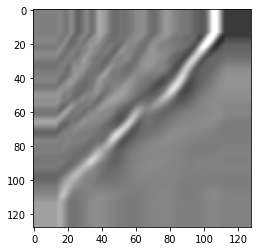

```python
plt.imshow(check[0][0].permute(2,1,0))
```

```python
FLAGS = {}
FLAGS['data_dir'] = "../competition_data"
FLAGS['batch_size'] = 16
FLAGS['num_workers'] = 4
FLAGS['learning_rate'] = 1e-9
FLAGS['num_epochs'] = 3
FLAGS['log_dir']='./tensorboard/'
```

#### loss

```python
def acc(pred,mask,center=False):
  "calculates the accuracy"
  pred,mask= pred.detach().cpu().numpy(),mask.detach().cpu().numpy()
  if not center:
    pred,mask= size_correct(pred,mask)
  pred=pred>0
  res= (pred==mask).sum()
  return res
```

```python
"""
Lovasz-Softmax and Jaccard hinge loss in PyTorch
Maxim Berman 2018 ESAT-PSI KU Leuven (MIT License)
"""

from torch.autograd import Variable

def lovasz_grad(gt_sorted):
    """
    Computes gradient of the Lovasz extension w.r.t sorted errors
    See Alg. 1 in paper
    """
    p = len(gt_sorted)
    gts = gt_sorted.sum()
    intersection = gts - gt_sorted.float().cumsum(0)
    union = gts + (1 - gt_sorted).float().cumsum(0)
    jaccard = 1. - intersection / union
    if p > 1: # cover 1-pixel case
        jaccard[1:p] = jaccard[1:p] - jaccard[0:-1]
    return jaccard

# --------------------------- BINARY LOSSES ---------------------------


def lovasz_hinge(logits, labels, per_image=True, ignore=None):


    """
    Binary Lovasz hinge loss
      logits: [B, H, W] Variable, logits at each pixel (between -\infty and +\infty)
      labels: [B, H, W] Tensor, binary ground truth masks (0 or 1)
      per_image: compute the loss per image instead of per batch
      ignore: void class id
    """
    logits= logits.squeeze(1)
    labels= labels.squeeze(1)

    if per_image:
        loss = mean(lovasz_hinge_flat(*flatten_binary_scores(log.unsqueeze(0), lab.unsqueeze(0), ignore))
                          for log, lab in zip(logits, labels))
    else:
        loss = lovasz_hinge_flat(*flatten_binary_scores(logits, labels, ignore))
    return loss


def lovasz_hinge_flat(logits, labels):
    """
    Binary Lovasz hinge loss
      logits: [P] Variable, logits at each prediction (between -\infty and +\infty)
      labels: [P] Tensor, binary ground truth labels (0 or 1)
      ignore: label to ignore
    """
    if len(labels) == 0:
        # only void pixels, the gradients should be 0
        return logits.sum() * 0.
    signs = 2. * labels.float() - 1.
    errors = (1. - logits * Variable(signs))
    errors_sorted, perm = torch.sort(errors, dim=0, descending=True)
    perm = perm.data
    gt_sorted = labels[perm]
    grad = lovasz_grad(gt_sorted)
    loss = torch.dot(F.elu(errors_sorted)+1, Variable(grad))
    return loss


def flatten_binary_scores(scores, labels, ignore=None):
    """
    Flattens predictions in the batch (binary case)
    Remove labels equal to 'ignore'
    """
    scores = scores.view(-1)
    labels = labels.view(-1)
    if ignore is None:
        return scores, labels
    valid = (labels != ignore)
    vscores = scores[valid]
    vlabels = labels[valid]
    return vscores, vlabels


# --------------------------- HELPER FUNCTIONS ---------------------------
def isnan(x):
    return x != x


def mean(l, ignore_nan=False, empty=0):
    """
    nanmean compatible with generators.
    """
    l = iter(l)
    if ignore_nan:
        l = ifilterfalse(isnan, l)
    try:
        n = 1
        acc = next(l)
    except StopIteration:
        if empty == 'raise':
            raise ValueError('Empty mean')
        return empty
    for n, v in enumerate(l, 2):
        acc += v
    if n == 1:
        return acc
    return acc / n
```

```python
"this function makes sure that metric is computed on 101x101 so that there is a better correlation with kaggle score."
def size_correct(logits,mask):
  if logits.shape[-1]==128:
    logits_= logits[:,:,13:-14,13:-14]
    mask_= mask[:,:,13:-14,13:-14]
  if logits.shape[-1]==128*2:
    logits_= logits[:,:,27:-27,27:-27]
    mask_= mask[:,:,27:-27,27:-27]
  return logits_,mask_
```

```python
class LovaszLoss(nn.Module):
  def forward(self,logits,targets):
    assert(len(logits.shape)==4)
    return lovasz_hinge(logits,targets,per_image=True)
```

### Model Preparation

```python
def train_loop_fn(loader):
  model.train()
  loss_,iou_,acc_=0.,0.,0.
  for x ,(image, mask) in enumerate(loader):
    mask=mask.to(device)
    image= image.to(device)
    y_pred = model(image)
    loss = loss_fn(y_pred, mask)
    loss_+= loss.item()
    optimizer.zero_grad()
    loss.backward()
    optimizer.step()
    ACC=acc(y_pred,mask)
    IOU= iou_metric(y_pred,mask)
    acc_+=ACC.item()
    iou_+=IOU.item()
    if scheduler:
      scheduler.step()

  loss_/=len(loader)
  iou_/=len(loader)
  acc_/=(len(train)*101*101)
  print('Train[{}]: Loss={:.5f} IOU={:.3f} ACC={:.3f}'.format(
        x, loss_,iou_,acc_))

  return loss_,iou_,acc_
```

```python
def test_loop_fn(loader):
  loss_,iou_,acc_=0.,0.,0.,
  model.eval()
  with torch.no_grad():
    for image, mask in  loader:
      image = image.to(device)
      mask=mask.to(device)
      y_pred= model(image)
      loss = loss_fn(y_pred, mask)
      loss_+= loss.item()
      ACC=acc(y_pred,mask)
      IOU= iou_metric(y_pred,mask)
      acc_+=ACC.item()
      iou_+=IOU.item()
  loss_ /=len(loader)
  iou_/=len(loader)
  acc_/=(len(val)*1.0*101*101)
  # if epoch>30:
  # scheduler.step(iou_)
  early_stopping(iou_,model)
  print('Validation: Loss={:.5f},IOU={:.3f} ACC={:.3f}'.format(
      loss_,iou_,acc_))
  return loss_,iou_,acc_
```

```python
#https://www.kaggle.com/c/tgs-salt-identification-challenge/discussion/67693
class ConvBn2d(nn.Module):
    def __init__(self, in_channels, out_channels, kernel_size=(3,3), stride=(1,1), padding=(1,1)):
        super(ConvBn2d, self).__init__()

        self.conv = nn.Conv2d(in_channels, out_channels, kernel_size=kernel_size, stride=stride, padding=padding, bias=False)
        self.bn = nn.BatchNorm2d(out_channels)

    def forward(self, z):
        x = self.conv(z)
        x = self.bn(x)
        return x

class Decoder(nn.Module):
    def __init__(self, in_channels, channels, out_channels ):
        super(Decoder, self).__init__()
        self.conv1 =  ConvBn2d(in_channels,  channels, kernel_size=3, padding=1)
        self.conv2 =  ConvBn2d(channels, out_channels, kernel_size=3, padding=1)

    def forward(self, x ):
        x = F.upsample(x, scale_factor=2, mode='bilinear', align_corners=True)#False
        x = F.relu(self.conv1(x),inplace=True)
        x = F.relu(self.conv2(x),inplace=True)
        return x

class Baseline(nn.Module):

    def __init__(self ):
        super().__init__()
        self.resnet = torchvision.models.resnet34(pretrained=True)

        self.conv1 = nn.Sequential(
            self.resnet.conv1,
            self.resnet.bn1,
            self.resnet.relu,
        )# 64
        self.encoder2 = self.resnet.layer1  # 64
        self.encoder3 = self.resnet.layer2  #128
        self.encoder4 = self.resnet.layer3  #256
        self.encoder5=  self.resnet.layer4  #512

        self.center = nn.Sequential(
            nn.Conv2d(512, 64, kernel_size=3, padding=1),
            nn.ReLU(inplace=True),
        )

        self.decoder5 = Decoder(512+64, 512, 64)
        self.decoder4 = Decoder(256+64, 256, 64)
        self.decoder3 = Decoder(128+64, 128,  64)
        self.decoder2 = Decoder(64+64  , 64,  64)


        self.logit    = nn.Sequential(
            nn.Conv2d(64, 32, kernel_size=3, padding=1),
            nn.ReLU(inplace=True),
            nn.Conv2d(32,  1, kernel_size=1, padding=0),
        )


    def forward(self, x):

        x = self.conv1(x)
        e2 = self.encoder2( x)  #; print('e2',e2.size())
        e3 = self.encoder3(e2)  #; print('e3',e3.size())
        e4 = self.encoder4(e3)  #; print('e4',e4.size())
        e5 = self.encoder5(e4)  #; print('e5',e5.size())

        f = self.center(e5)

        f = self.decoder5(torch.cat([f, e5], 1))  #; print('d5',f.size())
        f = self.decoder4(torch.cat([f, e4], 1))  #; print('d4',f.size())
        f = self.decoder3(torch.cat([f, e3], 1))  #; print('d3',f.size())
        f = self.decoder2(torch.cat([f, e2], 1))  #; print('d2',f.size())

        logit = self.logit(f)                     #; print('logit',logit.size())
        return logit

model=Baseline()
```

```
Downloading: "https://download.pytorch.org/models/resnet34-333f7ec4.pth" to /root/.cache/torch/hub/checkpoints/resnet34-333f7ec4.pth
```

```python
kf = StratifiedKFold(10,shuffle=True,random_state=seed)
for fold, (trn_idx,val_idx) in enumerate(kf.split(file_list,coverage)):
    if fold!=0 :
      continue
    print('***************************************************')
    print('*******************   fold  %d   *******************' % fold)
    print('********************************************')

    file_list_train= [x for i,x in enumerate(file_list) if i in trn_idx]
    file_list_val= [x for i,x in enumerate(file_list) if i in val_idx]
    train = TGSSaltDataset(train_path, file_list_train,augment=transform_test)#minimal augmentations for baseline model
    val = TGSSaltDataset(train_path, file_list_val,augment= transform_test)
    writer =SummaryWriter(FLAGS['log_dir']+'Baseline')

    train_loader = torch.utils.data.DataLoader(
        train,
        batch_size=64,
        num_workers=4,
        drop_last=False,worker_init_fn=_init_fn)
    test_loader = torch.utils.data.DataLoader(
        val,
        batch_size=FLAGS['batch_size']*5,
        shuffle=False,
        num_workers=2,
        drop_last=False,worker_init_fn=_init_fn)

    set_seed()
    device = 'cuda'
    model = model.to(device)
    loss_fn = nn.BCEWithLogitsLoss()
    optimizer = torch.optim.Adam(model.parameters(),lr= 3e-4)

    for epoch in range(1,31):
      train_loss,train_iou,train_acc=train_loop_fn(train_loader)
      print("Finished training epoch {}".format(epoch))
      val_loss,val_iou,val_acc= test_loop_fn(test_loader)
      if epoch==30:
        torch.save(model.state_dict(), './models/baseline.pth')
      writer.add_scalars('loss_exp',{'train':train_loss,'val':val_loss},epoch)
      writer.add_scalars('IOU',{'train':train_iou,'val':val_iou},epoch)
```

```
*******************   fold  0   *******************
Train[56]: Loss=0.19045 IOU=0.671 ACC=0.935
Finished training epoch 1
Validation: Loss=0.18495,IOU=0.679 ACC=0.932
Train[56]: Loss=0.16968 IOU=0.705 ACC=0.941
Finished training epoch 2
Validation: Loss=0.15853,IOU=0.712 ACC=0.940
Train[56]: Loss=0.14113 IOU=0.727 ACC=0.951
Finished training epoch 3
Validation: Loss=0.14940,IOU=0.737 ACC=0.947
Train[56]: Loss=0.12935 IOU=0.755 ACC=0.955
Finished training epoch 4
Validation: Loss=0.16131,IOU=0.718 ACC=0.941
Train[56]: Loss=0.11506 IOU=0.760 ACC=0.960
Finished training epoch 5
Validation: Loss=0.35990,IOU=0.659 ACC=0.896
Train[56]: Loss=0.11235 IOU=0.756 ACC=0.962
Finished training epoch 6
Validation: Loss=0.17880,IOU=0.752 ACC=0.943
Train[56]: Loss=0.10761 IOU=0.771 ACC=0.963
Finished training epoch 7
Validation: Loss=0.19045,IOU=0.745 ACC=0.941
Train[56]: Loss=0.09349 IOU=0.788 ACC=0.967
Finished training epoch 8
Validation: Loss=0.15526,IOU=0.739 ACC=0.945
Train[56]: Loss=0.06920 IOU=0.818 ACC=0.977
Finished training epoch 9
Validation: Loss=0.13031,IOU=0.775 ACC=0.957
Train[56]: Loss=0.05859 IOU=0.835 ACC=0.980
Finished training epoch 10
Validation: Loss=0.17271,IOU=0.755 ACC=0.948
Train[56]: Loss=0.05477 IOU=0.839 ACC=0.980
Finished training epoch 11
Validation: Loss=0.15839,IOU=0.780 ACC=0.958
Train[56]: Loss=0.05399 IOU=0.839 ACC=0.981
Finished training epoch 12
Validation: Loss=0.20756,IOU=0.711 ACC=0.940
Train[56]: Loss=0.07217 IOU=0.807 ACC=0.975
Finished training epoch 13
Validation: Loss=0.15976,IOU=0.763 ACC=0.952
```

[output cut: 36 more lines]

```
Train[56]: Loss=0.01623 IOU=0.919 ACC=0.993
Finished training epoch 26
Validation: Loss=0.21511,IOU=0.790 ACC=0.959
Train[56]: Loss=0.01529 IOU=0.923 ACC=0.993
Finished training epoch 27
Validation: Loss=0.22262,IOU=0.794 ACC=0.961
Train[56]: Loss=0.01415 IOU=0.926 ACC=0.993
Finished training epoch 28
Validation: Loss=0.23453,IOU=0.796 ACC=0.959
Train[56]: Loss=0.01463 IOU=0.924 ACC=0.993
Finished training epoch 29
Validation: Loss=0.23092,IOU=0.796 ACC=0.959
Train[56]: Loss=0.01507 IOU=0.920 ACC=0.993
Finished training epoch 30
Validation: Loss=0.21520,IOU=0.785 ACC=0.959
```

```python
%reload_ext tensorboard
%tensorboard --logdir {FLAGS['log_dir']+'Baseline'}
```

Clearly overfitting as seen from above.lets add augmentations to regularise the training.Dropout wasn't chosen here as it slows the training.

```python
transform_train = Compose([
    HorizontalFlip(p=.5),
     Compose([RandomCrop(90,90),
     Resize(101,101)],p=.2),
    OneOf([RandomBrightness(.1),
    RandomContrast(.1),RandomGamma()],p=.2),
    PadIfNeeded(256//2,256//2,cv2.BORDER_REPLICATE),
    Normalize(mean=(0,0,0),std=(1,1,1,))])

transform_test= Compose([
PadIfNeeded(256//2,256//2,cv2.BORDER_REPLICATE),
Normalize(mean=(0,0,0),std=(1,1,1,))])

transform_train_lv = Compose([
    HorizontalFlip(p=.5),
     Compose([RandomCrop(80,80),
     Resize(101,101)],p=.4),
    OneOf([RandomBrightness(.1),
    RandomContrast(.1),RandomGamma()],p=.4),
    PadIfNeeded(256//2,256//2,cv2.BORDER_REPLICATE),
    Normalize(mean=(0,0,0),std=(1,1,1,))])
```

```python
kf = StratifiedKFold(10,shuffle=True,random_state=seed)
for fold, (trn_idx,val_idx) in enumerate(kf.split(file_list,coverage)):
    if fold!=0 :
      continue
    print('***************************************************')
    print('*******************   fold  %d   *******************' % fold)
    print('********************************************')

    file_list_train= [x for i,x in enumerate(file_list) if i in trn_idx]
    file_list_val= [x for i,x in enumerate(file_list) if i in val_idx]
    train = TGSSaltDataset(train_path, file_list_train,augment=transform_train)
    val = TGSSaltDataset(train_path, file_list_val,augment= transform_test)
    early_stopping = EarlyStopping(patience=80,path= './models/baseline_corrected.pth', verbose=False)
    writer =SummaryWriter(FLAGS['log_dir']+'Baseline_corrected')

    train_loader = torch.utils.data.DataLoader(
        train,
        batch_size=64,
        num_workers=4,
        drop_last=False,worker_init_fn=_init_fn)
    test_loader = torch.utils.data.DataLoader(
        val,
        batch_size=FLAGS['batch_size']*5,
        shuffle=False,
        num_workers=2,
        drop_last=False,worker_init_fn=_init_fn)

    set_seed()
    device = 'cuda'
    model=Baseline()
    model = model.to(device)
    loss_fn = nn.BCEWithLogitsLoss()
    optimizer = torch.optim.Adam(model.parameters(),lr= 3e-4)

    for epoch in range(1,51):
      train_loss,train_iou,train_acc=train_loop_fn(train_loader)
      print("Finished training epoch {}".format(epoch))
      val_loss,val_iou,val_acc= test_loop_fn(test_loader)
      writer.add_scalars('loss_exp',{'train':train_loss,'val':val_loss},epoch)
      writer.add_scalars('IOU',{'train':train_iou,'val':val_iou},epoch)
```

```
*******************   fold  0   *******************
Train[56]: Loss=0.36946 IOU=0.533 ACC=0.858
Finished training epoch 1
Validation: Loss=0.24362,IOU=0.586 ACC=0.910
Train[56]: Loss=0.26712 IOU=0.617 ACC=0.898
Finished training epoch 2
Validation: Loss=0.23556,IOU=0.614 ACC=0.917
Train[56]: Loss=0.24512 IOU=0.645 ACC=0.908
Finished training epoch 3
Validation: Loss=0.18234,IOU=0.709 ACC=0.932
Train[56]: Loss=0.22686 IOU=0.675 ACC=0.914
Finished training epoch 4
Validation: Loss=0.16146,IOU=0.733 ACC=0.934
Train[56]: Loss=0.21982 IOU=0.675 ACC=0.914
Finished training epoch 5
Validation: Loss=0.15068,IOU=0.747 ACC=0.940
Train[56]: Loss=0.21096 IOU=0.690 ACC=0.918
Finished training epoch 6
Validation: Loss=0.15916,IOU=0.744 ACC=0.938
Train[56]: Loss=0.21764 IOU=0.684 ACC=0.912
Finished training epoch 7
Validation: Loss=0.14960,IOU=0.741 ACC=0.941
Train[56]: Loss=0.20333 IOU=0.702 ACC=0.921
Finished training epoch 8
Validation: Loss=0.14906,IOU=0.753 ACC=0.940
Train[56]: Loss=0.19298 IOU=0.718 ACC=0.927
Finished training epoch 9
Validation: Loss=0.21187,IOU=0.664 ACC=0.926
Train[56]: Loss=0.19797 IOU=0.715 ACC=0.921
Finished training epoch 10
Validation: Loss=0.14262,IOU=0.752 ACC=0.939
Train[56]: Loss=0.19515 IOU=0.716 ACC=0.924
Finished training epoch 11
Validation: Loss=0.13798,IOU=0.749 ACC=0.946
Train[56]: Loss=0.19545 IOU=0.712 ACC=0.924
Finished training epoch 12
Validation: Loss=0.88848,IOU=0.251 ACC=0.732
Train[56]: Loss=0.20010 IOU=0.704 ACC=0.920
Finished training epoch 13
Validation: Loss=0.18466,IOU=0.761 ACC=0.933
```

[output cut: 96 more lines]

```
Train[56]: Loss=0.14483 IOU=0.768 ACC=0.942
Finished training epoch 46
Validation: Loss=0.12203,IOU=0.796 ACC=0.957
Train[56]: Loss=0.13473 IOU=0.782 ACC=0.947
Finished training epoch 47
Validation: Loss=0.13747,IOU=0.793 ACC=0.948
Train[56]: Loss=0.12944 IOU=0.785 ACC=0.947
Finished training epoch 48
Validation: Loss=0.12505,IOU=0.815 ACC=0.963
Train[56]: Loss=0.13839 IOU=0.778 ACC=0.945
Finished training epoch 49
Validation: Loss=0.10488,IOU=0.812 ACC=0.962
Train[56]: Loss=0.13599 IOU=0.785 ACC=0.944
Finished training epoch 50
Validation: Loss=0.11148,IOU=0.811 ACC=0.958
```

```python
kf = StratifiedKFold(10,shuffle=True,random_state=seed)
for fold, (trn_idx,val_idx) in enumerate(kf.split(file_list,coverage)):
    if fold!=0 :
      continue
    print('****************************************************')
    print('*******************   fold  %d   *******************' % fold)
    print('****************************************************')

    file_list_train= [x for i,x in enumerate(file_list) if i in trn_idx]
    file_list_val= [x for i,x in enumerate(file_list) if i in val_idx]
    train = TGSSaltDataset(train_path, file_list_train,augment=transform_train)
    val = TGSSaltDataset(train_path, file_list_val,augment= transform_test)
    writer =SummaryWriter(FLAGS['log_dir']+'Baseline_lovasz')

    train_loader = torch.utils.data.DataLoader(
        train,
        batch_size=64,
        num_workers=4,
        drop_last=False,worker_init_fn=_init_fn)
    test_loader = torch.utils.data.DataLoader(
        val,
        batch_size=FLAGS['batch_size']*5,
        shuffle=False,
        num_workers=2,
        drop_last=False,worker_init_fn=_init_fn)

    set_seed()
    device = 'cuda'
    model=Baseline()
    model.load_state_dict(torch.load(f'./models/baseline_corrected.pth'),strict=False)
    model.to(device)
    loss_fn = LovaszLoss()
    optimizer = torch.optim.Adam(model.parameters(),lr= 1e-4)
    scheduler=torch.optim.lr_scheduler.CyclicLR(optimizer, base_lr=1e-4, max_lr=1e-3, step_size_up=280, step_size_down=None, mode='triangular2', cycle_momentum=False,last_epoch=-1)
    early_stopping = EarlyStopping(patience=80,path= './models/baselinelovasz.pth', verbose=False)

    for epoch in range(1,51):############
      train_loss,train_iou,train_acc=train_loop_fn(train_loader)
      print("Finished training epoch {}".format(epoch))
      val_loss,val_iou,val_acc= test_loop_fn(test_loader)
      writer.add_scalars('loss_exp',{'train':train_loss,'val':val_loss},epoch)
      writer.add_scalars('IOU',{'train':train_iou,'val':val_iou},epoch)
```

```
*******************   fold  0   *******************
Train[56]: Loss=0.91870 IOU=0.773 ACC=0.944
Finished training epoch 1
Validation: Loss=0.83149,IOU=0.798 ACC=0.947
Train[56]: Loss=0.91818 IOU=0.740 ACC=0.916
Finished training epoch 2
Validation: Loss=1.00649,IOU=0.746 ACC=0.938
Train[56]: Loss=1.07343 IOU=0.718 ACC=0.904
Finished training epoch 3
Validation: Loss=1.28495,IOU=0.718 ACC=0.930
Train[56]: Loss=1.15620 IOU=0.705 ACC=0.901
Finished training epoch 4
Validation: Loss=1.58985,IOU=0.625 ACC=0.871
Train[56]: Loss=1.26850 IOU=0.664 ACC=0.882
Finished training epoch 5
Validation: Loss=2.01842,IOU=0.551 ACC=0.889
Train[56]: Loss=1.17512 IOU=0.675 ACC=0.882
Finished training epoch 6
Validation: Loss=1.00265,IOU=0.757 ACC=0.936
Train[56]: Loss=1.10840 IOU=0.697 ACC=0.889
Finished training epoch 7
Validation: Loss=1.02445,IOU=0.716 ACC=0.895
Train[56]: Loss=1.00361 IOU=0.724 ACC=0.904
Finished training epoch 8
Validation: Loss=0.87646,IOU=0.778 ACC=0.937
Train[56]: Loss=0.92834 IOU=0.740 ACC=0.907
Finished training epoch 9
Validation: Loss=0.80448,IOU=0.808 ACC=0.945
Train[56]: Loss=0.86711 IOU=0.738 ACC=0.901
Finished training epoch 10
Validation: Loss=0.79452,IOU=0.806 ACC=0.945
Train[56]: Loss=0.83317 IOU=0.751 ACC=0.907
Finished training epoch 11
Validation: Loss=0.74026,IOU=0.819 ACC=0.954
Train[56]: Loss=0.83005 IOU=0.746 ACC=0.905
Finished training epoch 12
Validation: Loss=0.78383,IOU=0.805 ACC=0.951
Train[56]: Loss=0.85709 IOU=0.744 ACC=0.901
Finished training epoch 13
Validation: Loss=0.86906,IOU=0.792 ACC=0.941
```

[output cut: 96 more lines]

```
Train[56]: Loss=0.63945 IOU=0.787 ACC=0.917
Finished training epoch 46
Validation: Loss=0.74686,IOU=0.824 ACC=0.953
Train[56]: Loss=0.65463 IOU=0.795 ACC=0.924
Finished training epoch 47
Validation: Loss=0.68323,IOU=0.834 ACC=0.957
Train[56]: Loss=0.63579 IOU=0.794 ACC=0.919
Finished training epoch 48
Validation: Loss=0.71840,IOU=0.817 ACC=0.950
Train[56]: Loss=0.63948 IOU=0.787 ACC=0.917
Finished training epoch 49
Validation: Loss=0.72707,IOU=0.832 ACC=0.956
Train[56]: Loss=0.63401 IOU=0.791 ACC=0.923
Finished training epoch 50
Validation: Loss=0.70955,IOU=0.833 ACC=0.955
```

```python
%reload_ext tensorboard
%tensorboard --logdir {FLAGS['log_dir']+'Baseline_lovasz'}
```

```python
class ChannelAttentionGate(nn.Module):
    def __init__(self, channel, reduction=16):
        super(ChannelAttentionGate, self).__init__()
        self.avg_pool = nn.AdaptiveAvgPool2d(1)
        self.fc = nn.Sequential(
                nn.Linear(channel, channel // reduction),
                nn.ReLU(inplace=True),
                nn.Linear(channel // reduction, channel),
                nn.Sigmoid()
                 )

    def forward(self, x):
        b, c, _, _ = x.size()
        y = self.avg_pool(x).view(b, c)
        y = self.fc(y).view(b, c, 1, 1)
        return y


class SpatialAttentionGate(nn.Module):
    def __init__(self, channel, reduction=16):
        super(SpatialAttentionGate, self).__init__()
        self.fc1 = nn.Conv2d(channel, reduction, kernel_size=1, padding=0)
        self.fc2 = nn.Conv2d(reduction, 1, kernel_size=1, padding=0)

    def forward(self, x):
        x = self.fc1(x)
        x = F.relu(x, inplace=True)
        x = self.fc2(x)
        x = torch.sigmoid(x)

        return x

class Decoder(nn.Module):
    def __init__(self, in_channels, channels, out_channels ):
        super(Decoder, self).__init__()
        self.conv1 =  ConvBn2d(in_channels,  channels, kernel_size=3, padding=1)
        self.conv2 =  ConvBn2d(channels, out_channels, kernel_size=3, padding=1)
        self.cg= ChannelAttentionGate(out_channels)
        self.sg= SpatialAttentionGate(out_channels)

    def forward(self, x ):
        x = F.upsample(x, scale_factor=2, mode='bilinear', align_corners=True)#False
        x = F.relu(self.conv1(x),inplace=True)
        x = F.relu(self.conv2(x),inplace=True)
        g1= self.sg(x)
        g2= self.cg(x)
        x= g1*x+g2*x
        return x

class UNetScseHypercol(nn.Module):

    def __init__(self ):
        super().__init__()
        self.resnet = torchvision.models.resnet34(pretrained=True)

        self.conv1 = nn.Sequential(
            self.resnet.conv1,
            self.resnet.bn1,
            self.resnet.relu,
        )# 64
        self.encoder2 = self.resnet.layer1  # 64
        self.encoder3 = self.resnet.layer2  #128
        self.encoder4 = self.resnet.layer3  #256
        self.encoder5 = self.resnet.layer4  #512

        self.center = nn.Sequential(
            nn.Conv2d(512, 64, kernel_size=3, padding=1),
            nn.ReLU(inplace=True),
        )

        self.decoder5 = Decoder(512+64, 512, 64)
        self.decoder4 = Decoder(64+256, 256, 64)
        self.decoder3 = Decoder(64+128, 128,  64)
        self.decoder2 = Decoder( 64+ 64, 64, 64)


        self.logit    = nn.Sequential(
            nn.Conv2d(256, 32, kernel_size=3, padding=1),
            nn.ReLU(inplace=True),
            nn.Conv2d(32,  1, kernel_size=1, padding=0),
        )


    def forward(self, x):

        x = self.conv1(x)

        e2 = self.encoder2( x)  #; print('e2',e2.size())
        e3 = self.encoder3(e2)  #; print('e3',e3.size())
        e4 = self.encoder4(e3)  #; print('e4',e4.size())
        e5 = self.encoder5(e4)  #; print('e5',e5.size())
                            #; print('center',f.size())
        f = self.center(e5)
        # print(e5.shape,f.shape)

        d5 = self.decoder5(torch.cat([f, e5], 1))  #; print('d5',f.size())
        d4 = self.decoder4(torch.cat([d5, e4], 1))  #; print('d4',f.size())
        d3= self.decoder3(torch.cat([d4, e3], 1))  #; print('d3',f.size())
        d2 = self.decoder2(torch.cat([d3, e2], 1))  #; print('d2',f.size())

        f = torch.cat((d2,
          F.upsample(d3,scale_factor=2,mode='bilinear',align_corners=False),
          F.upsample(d4,scale_factor=4,mode='bilinear',align_corners=False),
          F.upsample(d5,scale_factor=8,mode='bilinear',align_corners=False),
                      ),1)

        logit = self.logit(f)                     #; print('logit',logit.size())
        return logit

model= UNetScseHypercol()
```

```python
transform_train = Compose([
    HorizontalFlip(p=.5),
     Compose([RandomCrop(90,90),
     Resize(101,101)],p=.3),
    OneOf([RandomBrightness(.1),
    RandomContrast(.1),RandomGamma()],p=.3),
    PadIfNeeded(256//2,256//2,cv2.BORDER_REPLICATE),
    Normalize(mean=(0,0,0),std=(1,1,1,))])
```

```python
kf = StratifiedKFold(10,shuffle=True,random_state=seed)
for fold, (trn_idx,val_idx) in enumerate(kf.split(file_list,coverage)):
    if fold!=0 :#######
      continue
    print('****************************************************')
    print('*******************   fold  %d   *******************' % fold)
    print('****************************************************')

    file_list_train= [x for i,x in enumerate(file_list) if i in trn_idx]
    file_list_val= [x for i,x in enumerate(file_list) if i in val_idx]
    train = TGSSaltDataset(train_path, file_list_train,augment=transform_train)
    val = TGSSaltDataset(train_path, file_list_val,augment= transform_test)
    writer =SummaryWriter(FLAGS['log_dir']+'scse')

    train_loader = torch.utils.data.DataLoader(
        train,
        batch_size=32,
        num_workers=4,
        drop_last=False,worker_init_fn=_init_fn)
    test_loader = torch.utils.data.DataLoader(
        val,
        batch_size=FLAGS['batch_size']*5,
        shuffle=False,
        num_workers=2,
        drop_last=False,worker_init_fn=_init_fn)

    set_seed()
    device = 'cuda'
    model = model.to(device)

    loss_fn= nn.BCEWithLogitsLoss()
    optimizer= torch.optim.Adam(model.parameters(),lr=3e-4)
    early_stopping = EarlyStopping(patience=80,path= './models/scse.pth', verbose=False)
    scheduler= None

    for epoch in range(1,21):############
      train_loss,train_iou,train_acc=train_loop_fn(train_loader)
      print("Finished training epoch {}".format(epoch))
      val_loss,val_iou,val_acc= test_loop_fn(test_loader)
      writer.add_scalars('loss_exp',{'train':train_loss,'val':val_loss},epoch)
      writer.add_scalars('IOU',{'train':train_iou,'val':val_iou},epoch)


    loss_fn = LovaszLoss()
    optimizer= torch.optim.Adam(model.parameters(),lr=1e-4)

    for epoch in range(21,91):
      train_loss,train_iou,train_acc=train_loop_fn(train_loader)
      print("Finished training epoch {}".format(epoch))
      val_loss,val_iou,val_acc= test_loop_fn(test_loader)
      writer.add_scalars('loss_exp',{'train':train_loss,'val':val_loss},epoch)
      writer.add_scalars('IOU',{'train':train_iou,'val':val_iou},epoch)

    scheduler=torch.optim.lr_scheduler.CyclicLR(optimizer, base_lr=1e-4, max_lr=1e-3, step_size_up=560*2, step_size_down=None, mode='triangular2', cycle_momentum=False,last_epoch=-1)


    for epoch in range(91,171):
      train_loss,train_iou,train_acc=train_loop_fn(train_loader)
      print("Finished training epoch {}".format(epoch))
      val_loss,val_iou,val_acc= test_loop_fn(test_loader)
      writer.add_scalars('loss_exp',{'train':train_loss,'val':val_loss},epoch)
      writer.add_scalars('IOU',{'train':train_iou,'val':val_iou},epoch)
```

```
*******************   fold  0   *******************
Train[112]: Loss=0.19873 IOU=0.730 ACC=0.916
Finished training epoch 1
Validation: Loss=0.16866,IOU=0.794 ACC=0.944
Train[112]: Loss=0.19705 IOU=0.728 ACC=0.917
Finished training epoch 2
Validation: Loss=0.12604,IOU=0.801 ACC=0.952
Train[112]: Loss=0.19345 IOU=0.733 ACC=0.920
Finished training epoch 3
Validation: Loss=0.17322,IOU=0.811 ACC=0.953
Train[112]: Loss=0.20115 IOU=0.730 ACC=0.916
Finished training epoch 4
Validation: Loss=0.14015,IOU=0.800 ACC=0.948
Train[112]: Loss=0.19690 IOU=0.723 ACC=0.918
Finished training epoch 5
Validation: Loss=0.12960,IOU=0.815 ACC=0.954
Train[112]: Loss=0.18784 IOU=0.735 ACC=0.922
Finished training epoch 6
Validation: Loss=0.16481,IOU=0.803 ACC=0.952
Train[112]: Loss=0.18446 IOU=0.739 ACC=0.923
Finished training epoch 7
Validation: Loss=0.13541,IOU=0.800 ACC=0.952
Train[112]: Loss=0.19176 IOU=0.736 ACC=0.921
Finished training epoch 8
Validation: Loss=0.15040,IOU=0.815 ACC=0.955
Train[112]: Loss=0.18802 IOU=0.735 ACC=0.926
Finished training epoch 9
Validation: Loss=0.14746,IOU=0.795 ACC=0.953
Train[112]: Loss=0.19867 IOU=0.724 ACC=0.916
Finished training epoch 10
Validation: Loss=0.14326,IOU=0.805 ACC=0.954
Train[112]: Loss=0.18391 IOU=0.739 ACC=0.923
Finished training epoch 11
Validation: Loss=0.14899,IOU=0.810 ACC=0.951
Train[112]: Loss=0.18247 IOU=0.745 ACC=0.928
Finished training epoch 12
Validation: Loss=0.16581,IOU=0.816 ACC=0.955
Train[112]: Loss=0.19047 IOU=0.736 ACC=0.922
Finished training epoch 13
Validation: Loss=0.17863,IOU=0.808 ACC=0.949
```

[output cut: 456 more lines]

```
Train[112]: Loss=0.62338 IOU=0.794 ACC=0.911
Finished training epoch 166
Validation: Loss=0.79807,IOU=0.819 ACC=0.925
Train[112]: Loss=0.63910 IOU=0.780 ACC=0.897
Finished training epoch 167
Validation: Loss=0.82690,IOU=0.824 ACC=0.931
Train[112]: Loss=0.66418 IOU=0.778 ACC=0.899
Finished training epoch 168
Validation: Loss=0.81700,IOU=0.824 ACC=0.933
Train[112]: Loss=0.65341 IOU=0.788 ACC=0.908
Finished training epoch 169
Validation: Loss=0.79778,IOU=0.832 ACC=0.936
Train[112]: Loss=0.63172 IOU=0.782 ACC=0.895
Finished training epoch 170
Validation: Loss=0.82647,IOU=0.825 ACC=0.930
```

```python
%reload_ext tensorboard
%tensorboard --logdir {FLAGS['log_dir']+'scse'}
```

```
Reusing TensorBoard on port 6007 (pid 359), started 1:03:53 ago. (Use '!kill 359' to kill it.)
```

lets try debugging the model to see the errors classified according to the classes.

```python
kf = StratifiedKFold(10,shuffle=True,random_state=seed)
for fold, (trn_idx,val_idx) in enumerate(kf.split(file_list,coverage)):
    if fold!=0 :#######
      continue
    file_list_train= [x for i,x in enumerate(file_list) if i in trn_idx]
    file_list_val= [x for i,x in enumerate(file_list) if i in val_idx]
train = TGSSaltDataset(train_path, file_list_train,augment=transform_test)
val = TGSSaltDataset(train_path, file_list_val,augment= transform_test)

train_loader = torch.utils.data.DataLoader(
    train,
    batch_size=32,
    num_workers=4,
    drop_last=False,worker_init_fn=_init_fn)
test_loader = torch.utils.data.DataLoader(
    val,
    batch_size=FLAGS['batch_size']*5,
    shuffle=False,
    num_workers=2,drop_last=False,worker_init_fn=_init_fn)
```

```python
all_predictions = []
for image,_ in tqdm(test_loader):
  with torch.no_grad():
    image = image.to(device)
    y_pred= model(image)
    y_pred = F.sigmoid(y_pred)
    all_predictions.append(y_pred)

val_predictions_stacked=torch.cat(all_predictions,0)
print(val_predictions_stacked.shape)
all_predictions=None
all_predictions = []
for image,_ in tqdm(train_loader):
  with torch.no_grad():
    image = image.to(device)
    bin,y_pred= model(image)
    y_pred = F.sigmoid(y_pred)
    all_predictions.append(y_pred)

train_predictions_stacked=torch.cat(all_predictions,0)
print(train_predictions_stacked.shape)
all_predictions=None
```

```
torch.Size([400, 1, 128, 128])
```

```
torch.Size([3600, 1, 128, 128])
```

```python
train_predictions_stacked=train_predictions_stacked.cpu().numpy()
val_predictions_stacked=val_predictions_stacked.cpu().numpy()
```

```python
from scipy.special import logit
# with open('predictions_debug2.npy', 'wb') as f:
#   np.save(f,train_predictions_stacked)
#   np.save(f, val_predictions_stacked)
with open('predictions_debug2.npy', 'rb') as f:
  trainp = np.load(f)
  valp = np.load(f)
  trainp= logit(trainp)##return logits instead of sigomoid outputs
  valp= logit(valp)
```

```python
loose_iou=[]
loose_loss=[]
coverage=np.array((depths_df['salt_content'][val_idx]))
for i in tqdm(range(len(val))):
  img,mask=val[i]
  """avg iou calculation for each coverage class"""
  iou=iou_metric(torch.from_numpy(valp)[i].unsqueeze(0),mask.unsqueeze(0),logits=False)
  loss= lovasz_hinge(torch.from_numpy(valp)[i],mask).numpy()
  loose_iou.append(iou)
  loose_loss.append(loss)

loose_iou_tr=[]
loose_loss_tr=[]
coverage=np.array((depths_df['salt_content'][trn_idx]))
for i in tqdm(range(len(train))):
  img,mask=train[i]
  """avg iou calculation for each coverage class"""
  iou=iou_metric(torch.from_numpy(trainp)[i].unsqueeze(0),mask.unsqueeze(0))
  loss= lovasz_hinge(torch.from_numpy(trainp)[i],mask).numpy()
  loose_iou_tr.append(iou)
  loose_loss_tr.append(loss)
```

```python
coverage=np.array((depths_df['salt_content']))
csv_=[]
for ind,idx in enumerate(val_idx):
  block= [idx,loose_iou[ind],loose_loss[ind].item(),coverage[idx],1]
  csv_.append(block)
for ind,idx in enumerate(trn_idx):
  block= [idx,loose_iou_tr[ind],loose_loss_tr[ind].item(),coverage[idx],0]
  csv_.append(block)
```

```python
import csv

with open("debug.csv", "w", newline="") as f:
    writer = csv.writer(f)
    writer.writerow(['idx', 'iou', 'loss_lovasz','coverage','is_val'])
    writer.writerows(csv_)
```

```python
debug= pd.read_csv('debug.csv')
debug.head()
```

|  | idx | iou | loss_lovasz | coverage | is_val |
| --- | --- | --- | --- | --- | --- |
| 0 | 38 | 0.7 | 0.764614 | 4 | 1 |
| 1 | 44 | 0.5 | 1.192690 | 0 | 1 |
| 2 | 46 | 0.0 | 2.006062 | 0 | 1 |
| 3 | 47 | 1.0 | 0.063098 | 8 | 1 |
| 4 | 50 | 1.0 | 0.001246 | 0 | 1 |

```python
debug.groupby(['iou']).count()['idx']
```

```
iou
0.0     187
0.1       6
0.2      10
0.3      16
0.4      35
0.5      37
0.6      68
0.7     103
0.8     198
0.9     418
1.0    2922
Name: idx, dtype: int64
```

```python
iou_0_val=debug[(debug['is_val']==1) & (debug['iou']==0.0)]
iou_0_trn=debug[(debug['is_val']==0) & (debug['iou']==0.0)]
```

```python
iou_0_val.groupby(['coverage']).count()
```

| coverage | idx | iou | loss_lovasz | is_val |
| --- | --- | --- | --- | --- |
| 0 | 21 | 21 | 21 | 21 |
| 1 | 6 | 6 | 6 | 6 |
| 2 | 4 | 4 | 4 | 4 |
| 3 | 4 | 4 | 4 | 4 |
| 4 | 1 | 1 | 1 | 1 |
| 5 | 2 | 2 | 2 | 2 |
| 6 | 5 | 5 | 5 | 5 |
| 8 | 3 | 3 | 3 | 3 |
| 10 | 1 | 1 | 1 | 1 |

```python
iou_0_trn.groupby(['coverage']).count()
```

| coverage | idx | iou | loss_lovasz | is_val |
| --- | --- | --- | --- | --- |
| 0 | 65 | 65 | 65 | 65 |
| 1 | 20 | 20 | 20 | 20 |
| 2 | 11 | 11 | 11 | 11 |
| 3 | 6 | 6 | 6 | 6 |
| 4 | 11 | 11 | 11 | 11 |
| 5 | 7 | 7 | 7 | 7 |
| 6 | 7 | 7 | 7 | 7 |
| 8 | 10 | 10 | 10 | 10 |
| 10 | 3 | 3 | 3 | 3 |

```python
valnp= np.array([x[1].numpy() for x in val])
trainnp= np.array([x[1].numpy() for x in train])
```

```python
legend1= np.ones([1,128,128])
legend1[:,64:,:]=0
legend2= np.ones([1,128,128])
legend2[:,:,64:]=0
```

```python
v_slice= (valp[iou_0_val.index.values]>0).squeeze(1)
h_slice= (valnp[iou_0_val.index.values]).squeeze(1)
h_slice=np.append(h_slice,legend1,0)
v_slice=np.append(v_slice,legend2,0)

# v_slice= (trainp[iou_0_trn.index.values-400]>0).squeeze(1)
# h_slice= (trainnp[iou_0_trn.index.values-400]).squeeze(1)
# v_slice=np.append(v_slice,legend1,0)
# h_slice=np.append(h_slice,legend2,0)
```

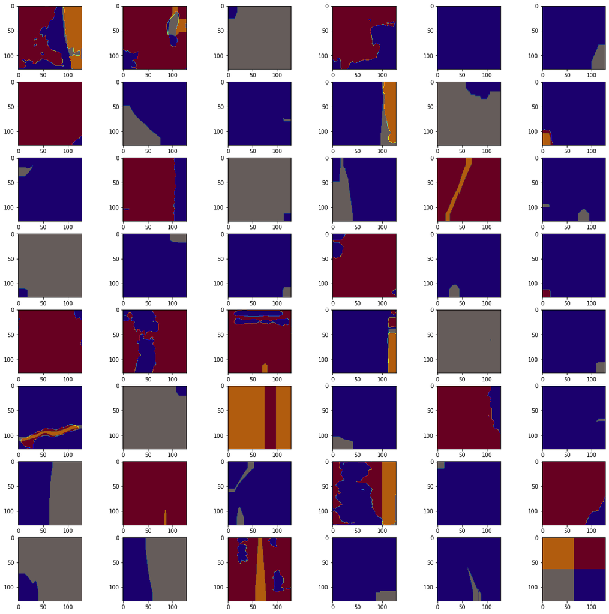

```python
w=20
h=20
fig=plt.figure(figsize=(20, 20))
columns = 6
rows = 8
for i in range(1, columns*rows +1):
    fig.add_subplot(rows, columns, i)
    plt.imshow(h_slice[i-1])
    plt.imshow(v_slice[i-1],cmap='jet',alpha=.6)
plt.show()
```

This shows small masks around corners and edges are hard for model to predict, some masks are predicted salt as nosalt.i.e false negatives are more.

```python
Fprate= sum([(valp[x]>0).sum()>0 and valnp[x].sum()==0 for x in range(len(valnp))])
Fnrate= sum([(valp[x]>0).sum()==0 and valnp[x].sum()>0 for x in range(len(valnp))])
Fprate,Fnrate
```

```
(11,24)
```